# Roman Emperors

Bela Szlovicsak

2022-12-23

## Exploratory Analysis

Reading the data

```r
emperors <- read_csv("https://raw.githubusercontent.com/rfordatascience/tidytuesday/master/data/2019/2019-08-13/emperors.csv")
```

Looking at basic values, and examining the variables.

```r
str(emperors)
```

```
## spc_tbl_ [68 × 16] (S3: spec_tbl_df/tbl_df/tbl/data.frame)
##  $ index      : num [1:68] 1 2 3 4 5 6 7 8 9 10 ...
##  $ name       : chr [1:68] "Augustus" "Tiberius" "Caligula" "Claudius" ...
##  $ name_full  : chr [1:68] "IMPERATOR CAESAR DIVI FILIVS AVGVSTVS" "TIBERIVS CAESAR DIVI AVGVSTI FILIVS AVGVSTVS" "GAIVS IVLIVS CAESAR AVGVSTVS GERMANICVS" "TIBERIVS CLAVDIVS CAESAR AVGVSTVS GERMANICVS" ...
##  $ birth      : Date[1:68], format: "0062-09-23" "0041-11-16" ...
##  $ death      : Date[1:68], format: "0014-08-19" "0037-03-16" ...
##  $ birth_cty  : chr [1:68] "Rome" "Rome" "Antitum" "Lugdunum" ...
##  $ birth_prv  : chr [1:68] "Italia" "Italia" "Italia" "Gallia Lugdunensis" ...
##  $ rise       : chr [1:68] "Birthright" "Birthright" "Birthright" "Birthright" ...
##  $ reign_start: Date[1:68], format: "0026-01-16" "0014-09-18" ...
##  $ reign_end  : Date[1:68], format: "0014-08-19" "0037-03-16" ...
##  $ cause      : chr [1:68] "Assassination" "Assassination" "Assassination" "Assassination" ...
##  $ killer     : chr [1:68] "Wife" "Other Emperor" "Senate" "Wife" ...
##  $ dynasty    : chr [1:68] "Julio-Claudian" "Julio-Claudian" "Julio-Claudian" "Julio-Claudian" ...
##  $ era        : chr [1:68] "Principate" "Principate" "Principate" "Principate" ...
##  $ notes      : chr [1:68] "birth, reign.start are BCE. Assign negative for correct ISO 8601 dates. Cause may have been Natural" "birth is BCE. Assign negative for correct ISO 8601 dates. Possibly assassinated by praetorian guard" "assassination may have only involved the Praetorian Guard" "birth…
##  $ verif_who  : chr [1:68] "Reddit user zonination" "Reddit user zonination" "Reddit user zonination" "Reddit user zonination" ...
##  - attr(*, "spec")=
##   .. cols(
##   ..   index = col_double(),
##   ..   name = col_character(),
##   ..   name_full = col_character(),
##   ..   birth = col_date(format = ""),
##   ..   death = col_date(format = ""),
##   ..   birth_cty = col_character(),
##   ..   birth_prv = col_character(),
##   ..   rise = col_character(),
##   ..   reign_start = col_date(format = ""),
##   ..   reign_end = col_date(format = ""),
##   ..   cause = col_character(),
##   ..   killer = col_character(),
##   ..   dynasty = col_character(),
##   ..   era = col_character(),
##   ..   notes = col_character(),
##   ..   verif_who = col_character()
##   .. )
##  - attr(*, "problems")=<externalptr>
```

```r
summary(emperors)
```

```
##      index           name            name_full             birth
##  Min.   : 1.00   Length:68          Length:68          Min.   :0002-12-24
##  1st Qu.:17.75   Class :character   Class :character   1st Qu.:0123-12-13
##  Median :34.50   Mode  :character   Mode  :character   Median :0201-01-01
##  Mean   :34.50                                         Mean   :0184-07-15
##  3rd Qu.:51.25                                         3rd Qu.:0250-01-01
##  Max.   :68.00                                         Max.   :0371-01-01
##                                                        NA's   :5
##      death             birth_cty          birth_prv             rise
##  Min.   :0014-08-19   Length:68          Length:68          Length:68
##  1st Qu.:0189-10-20   Class :character   Class :character   Class :character
##  Median :0251-08-08   Mode  :character   Mode  :character   Mode  :character
##  Mean   :0236-06-01
##  3rd Qu.:0310-09-25
##  Max.   :0395-01-17
##
##   reign_start           reign_end             cause
##  Min.   :0014-09-18   Min.   :0014-08-19   Length:68
##  1st Qu.:0173-01-17   1st Qu.:0189-10-20   Class :character
##  Median :0250-08-08   Median :0251-08-08   Mode  :character
##  Mean   :0228-06-24   Mean   :0236-02-08
##  3rd Qu.:0305-05-01   3rd Qu.:0306-11-06
##  Max.   :0379-01-01   Max.   :0395-01-17
##
##     killer            dynasty              era               notes
##  Length:68          Length:68          Length:68          Length:68
##  Class :character   Class :character   Class :character   Class :character
##  Mode  :character   Mode  :character   Mode  :character   Mode  :character
##
##
##
##
##   verif_who
##  Length:68
##  Class :character
##  Mode  :character
##
##
##
##
```

The dates are good if we need difference, because BCE dates are one less than in reality Next I make two variables, one of reign length, another of age at death.

```r
emperors_dur <- emperors %>%
  mutate(
    age = as.numeric(death-birth)/365,
    reign = as.numeric(reign_end - reign_start)/365
  ) %>%
  filter(age > 0)
```

#Exploring possible relationships

A relationship between age and length of reign?

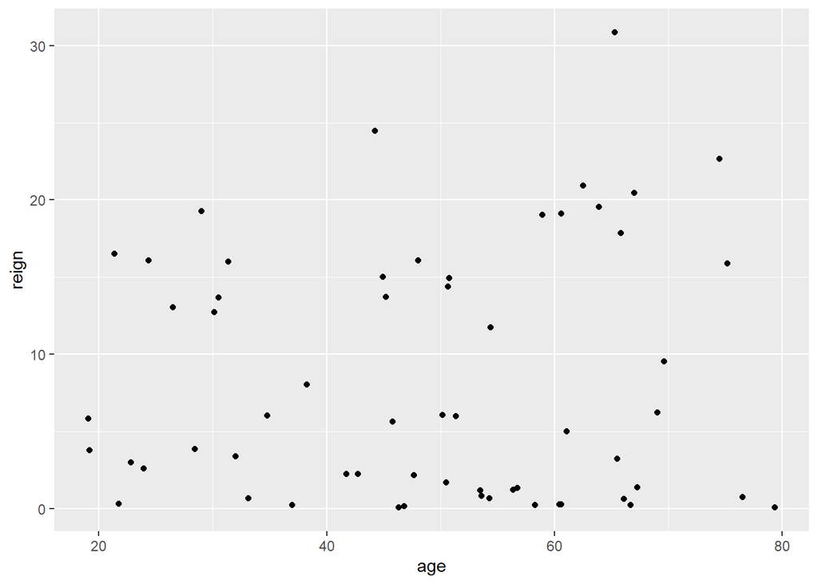

```r
ggplot(emperors_dur, aes(age, reign)) +
  geom_point()
```

Examining reign vs. cause of death

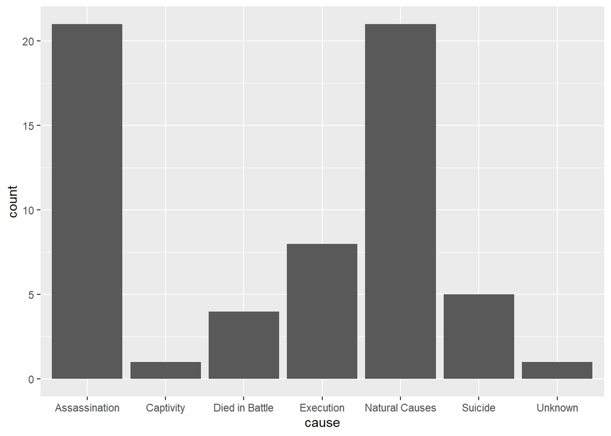

```r
ggplot(emperors_dur, aes(cause)) +
  geom_bar()
```

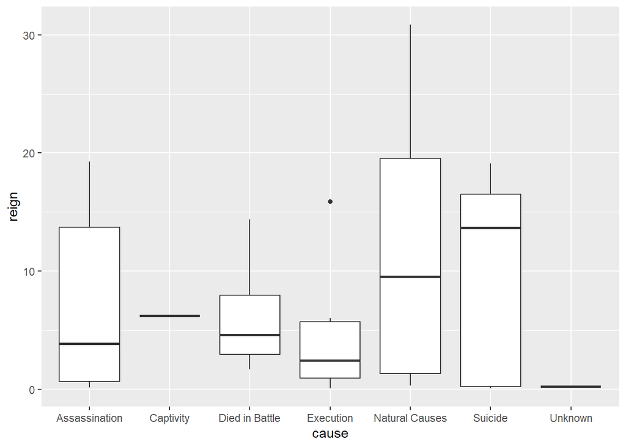

```r
ggplot(emperors_dur, aes(cause, reign)) +
  geom_boxplot()
```

Examining reign vs. mode of rising to power

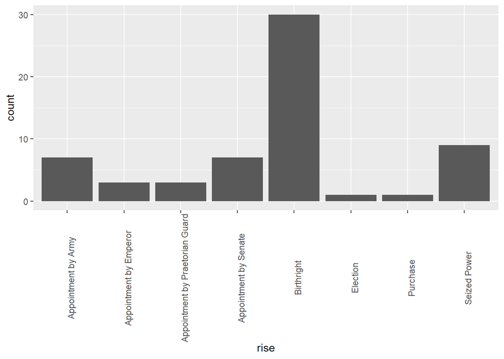

```r
ggplot(emperors_dur, aes(rise)) +
  geom_bar() +
  theme(axis.text.x = element_text(angle = 90))
```

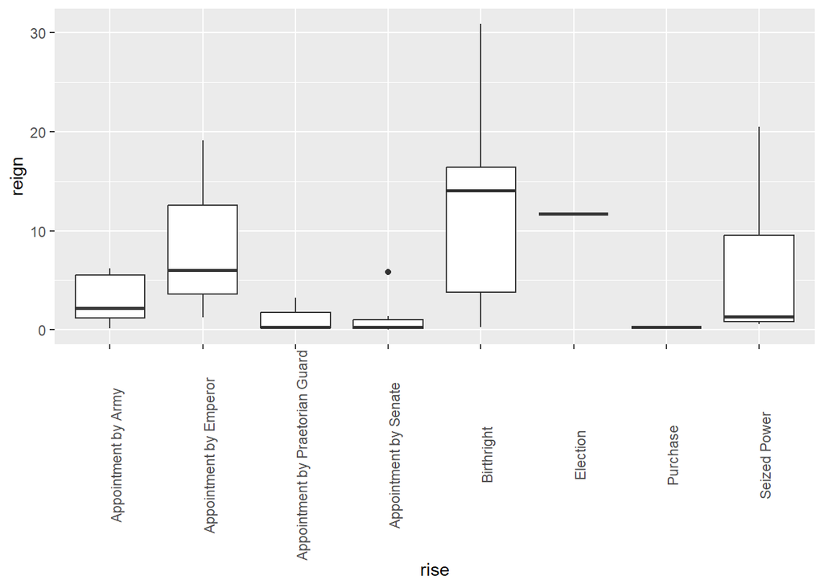

```r
ggplot(emperors_dur, aes(rise, reign)) +
  geom_boxplot() +
  theme(axis.text.x = element_text(angle = 90))
```

Examining cause of death vs. mode of rising to power

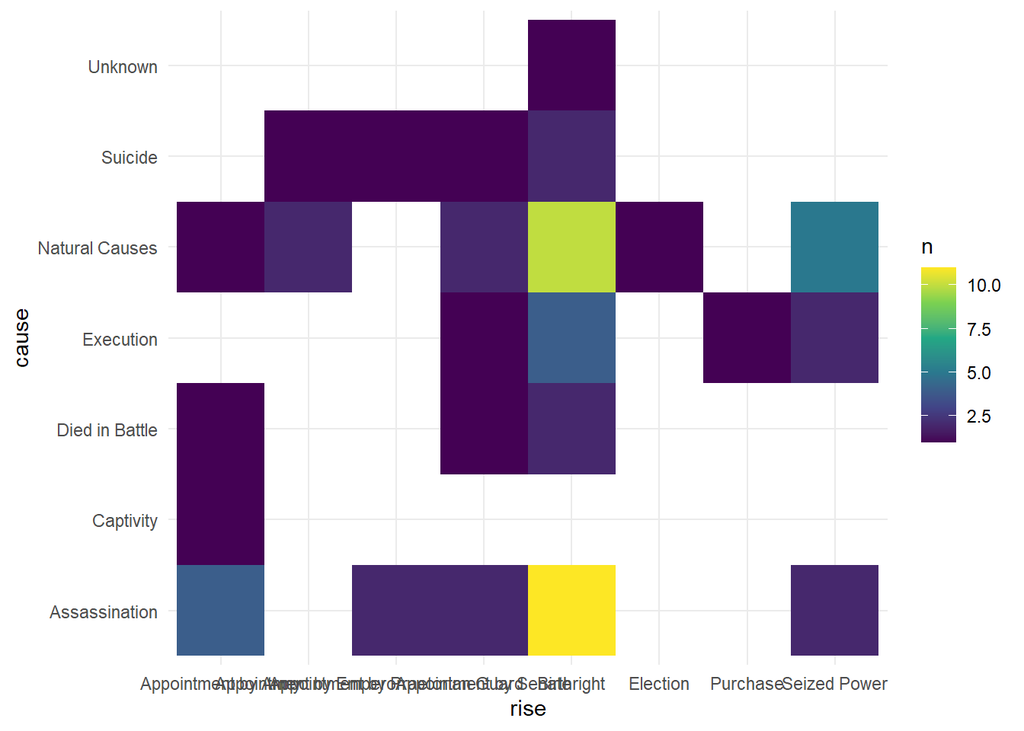

```r
emperors_dur %>%
  count(rise, cause) %>%
  ggplot( aes(rise, cause, fill = n)) +
  geom_tile() +
  theme(axis.text.x = element_text(angle = 90)) +
  scale_fill_viridis_c() +
  theme_minimal()
```

This last relationship seems worthy of examination, this could be done with a Fisher test

```r
emperors_dur %>%
  count(rise, cause) %>%
  pivot_wider(names_from = cause, values_from = n) %>%
  replace(is.na(.), 0) %>%
  column_to_rownames("rise") %>%
  as.matrix() %>%
  fisher.test(workspace = 20000000)
```

```
##
##  Fisher's Exact Test for Count Data
##
## data:  .
## p-value = 0.528
## alternative hypothesis: two.sided
```

Because of the very low counts, no real relationship can be estabilished

Examining age vs. cause of death

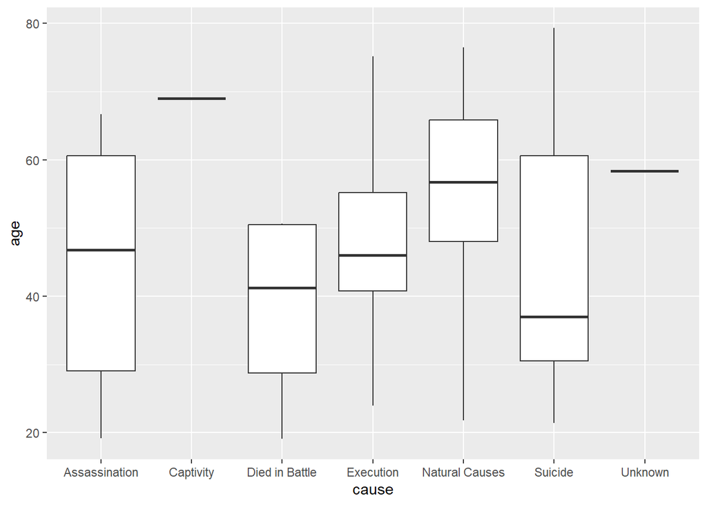

```r
ggplot(emperors_dur, aes(cause, age)) +
  geom_boxplot()
```

Examining age vs. mode of rising to power

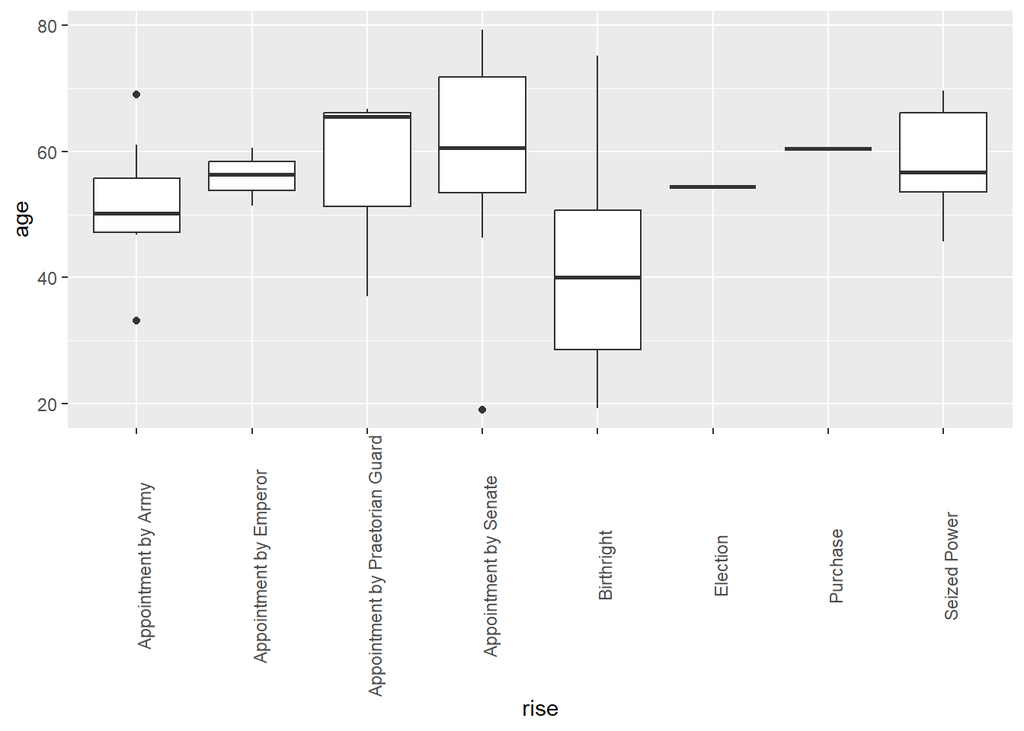

```r
ggplot(emperors_dur, aes(rise, age)) +
  geom_boxplot() +
  theme(axis.text.x = element_text(angle = 90))
```

Both rise and cause seem to have an effect on age, this can be checked with a linear model

```r
model1 <- lm(age ~ rise + cause +0, emperors_dur)

tidy(model1 ,conf.int = TRUE, conf.level = 0.95)
```

```
## # A tibble: 14 × 7
##    term                         estim…¹ std.e…² stati…³  p.value conf.…⁴ conf.…⁵
##    <chr>                          <dbl>   <dbl>   <dbl>    <dbl>   <dbl>   <dbl>
##  1 riseAppointment by Army        47.5     6.18   7.68  7.56e-10   35.0    59.9
##  2 riseAppointment by Emperor     49.3     9.61   5.12  5.53e- 6   29.9    68.6
##  3 riseAppointment by Praetori…   57.0     8.76   6.50  4.70e- 8   39.3    74.6
##  4 riseAppointment by Senate      56.3     6.28   8.96  9.75e-12   43.7    68.9
##  5 riseBirthright                 37.3     3.77   9.90  4.45e-13   29.7    44.9
##  6 riseElection                   43.3    15.3    2.83  6.84e- 3   12.5    74.1
##  7 risePurchase                   58.8    15.9    3.69  5.83e- 4   26.8    90.9
##  8 riseSeized Power               52.6     6.00   8.77  1.84e-11   40.6    64.7
##  9 causeCaptivity                 21.6    15.8    1.37  1.78e- 1  -10.2    53.3
## 10 causeDied in Battle            -6.55    8.03  -0.816 4.19e- 1  -22.7     9.61
## 11 causeExecution                  1.62    6.59   0.246 8.07e- 1  -11.6    14.9
## 12 causeNatural Causes            11.1     4.86   2.28  2.72e- 2    1.30   20.9
## 13 causeSuicide                   -1.68    7.65  -0.219 8.27e- 1  -17.1    13.7
## 14 causeUnknown                   21.0    15.0    1.40  1.68e- 1   -9.17   51.2
## # … with abbreviated variable names ¹estimate, ²std.error, ³statistic,
## #   ⁴conf.low, ⁵conf.high
```

Almost all confidence intervals for the causes of death contain 0, therefore this variable is not really adding anytting to this model, I’ll make a new one without including it.

```r
model2 <- lm(age ~ rise +0, emperors_dur)

tidy(model2, conf.int = TRUE, conf.level = 0.95)
```

```
## # A tibble: 8 × 7
##   term                          estim…¹ std.e…² stati…³  p.value conf.…⁴ conf.…⁵
##   <chr>                           <dbl>   <dbl>   <dbl>    <dbl>   <dbl>   <dbl>
## 1 riseAppointment by Army          51.2    5.76    8.88 4.51e-12    39.6    62.8
## 2 riseAppointment by Emperor       56.1    8.81    6.37 4.63e- 8    38.4    73.8
## 3 riseAppointment by Praetoria…    56.4    8.81    6.40 4.09e- 8    38.7    74.1
## 4 riseAppointment by Senate        58.5    5.76   10.2  4.93e-14    47.0    70.1
## 5 riseBirthright                   41.4    2.78   14.9  1.52e-20    35.8    47.0
## 6 riseElection                     54.4   15.3     3.57 7.74e- 4    23.8    85.0
## 7 risePurchase                     60.5   15.3     3.96 2.22e- 4    29.9    91.0
## 8 riseSeized Power                 59.2    5.08   11.6  3.23e-16    49.0    69.4
## # … with abbreviated variable names ¹estimate, ²std.error, ³statistic,
## #   ⁴conf.low, ⁵conf.high
```

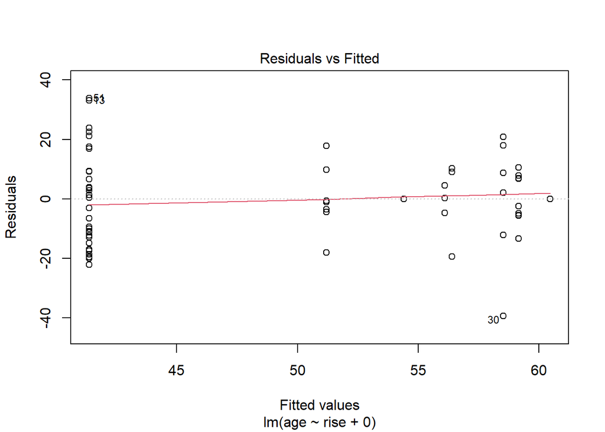

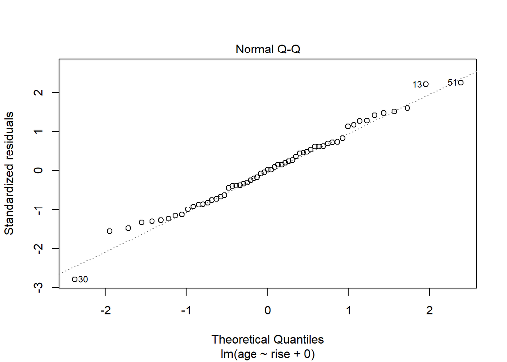

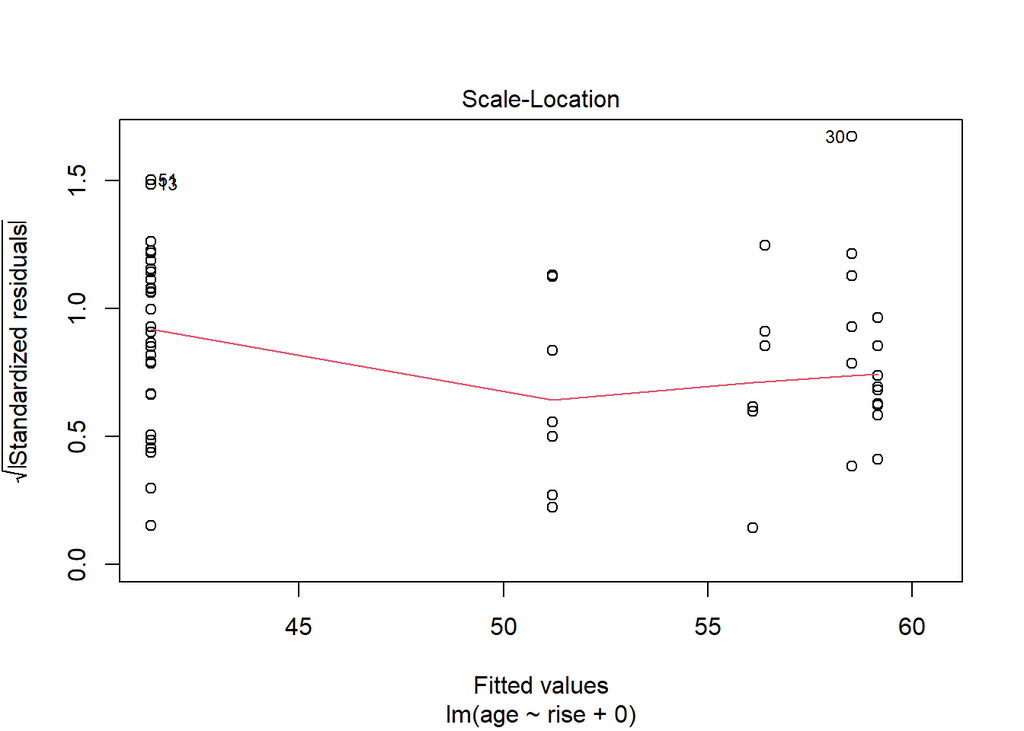

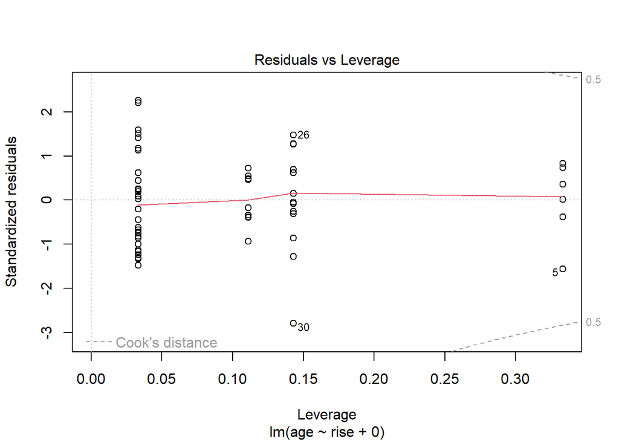

```r
plot(model2)
```

Most technical requirements are okay, but the data is not exactly heteroscadistic, therefore it’s not reliable.